# Stat 361 - Recitation 4

## İrem Tanrıverdi, iremt@metu.edu.tr

### 31.03.2022

## Sums and Mixtures

Sums and mixtures of a random variable is a special type of transformation.

**Convolution:** Basically, sums of independent random variables $(S= X_1+X_2+...+X_n = \sum_{i=1}^n {X_i})$

For example;

1. $X \sim N(1, 5)$
2. $Y \sim N(2, 3)$
3. $Z = X + Y \sim N(3, 8)$

or;

1. $v \sim \chi^2_2$
1. $u \sim \chi^2_6$
1. $z = v + u \sim \chi^2_8$

or;

1. $ w \sim gamma(2, 4)$
2. $ z \sim gamma(7, 4)$
3. $ s = w + z \sim gamma(9, 4)$

This are examples of convolution.

**Mixtures:** Mixtures can be defined as combination of continuous and discretes.

- If the random variable X has a distribution as a weighted sum $𝐹_𝑋(𝑥)=Σ𝜃_𝑖𝐹_{𝑋𝑖}(𝑥)$ for some sequence of $X_i$’s and $𝜃_𝑖>0$ such that $Σ𝜃_𝑖=1$, then X is a discrete mixture. The constant $𝜃_𝑖$’s are called as mixing weights.
- If the distribution of X is $𝐹_𝑋(𝑥)=∫𝐹_{𝑋|𝑌=𝑦}(𝑥)𝑓_𝑌(𝑦)𝑑𝑦$ for a family X|Y=y indexed by real numbers y and weighting function $f_Y$ such that $∫𝑓_𝑌(𝑦)𝑑𝑦 =1$, then X is a continuous mixture.
1. $X \sim N(1, 5)$
2. $Y \sim N(2, 3)$
3. $Z = 0.5X + 0.5Y$

or;

1. $ w \sim gamma(2, 4)$
2. $ z \sim gamma(7, 4)$
3. $ s = 0.7w + 0.3z $

# Transformation Methods

We know that there is relationship between some distributions (given at STAT 303 lecture).

### 1. Y $\sim$ N(0, 1) then $Y^2 \sim \chi^2_1$

### $\sum_{i=1}^n {Y_i} \sim \chi^2_n $

### 2. Z $\sim N(0, 1)$ and $V \sim \chi^2_\delta$ then,

### T = $\frac{Z}{\sqrt {V/\delta}} \sim t_\delta$

### 3. $V_1 \sim \chi^2_{k}$ and $V_2 \sim \chi^2_{l} $ then,

### F = $\frac{V_1/k}{V_2/l} \sim F_{k, l}$

### 4. U $\sim Exponential(\theta) = Gamma(1, \theta)$

### $\sum_{i=1}^t {U_i} \sim Gamma(t, \theta)$

### 5. U $\sim 𝐺𝑎𝑚𝑚𝑎(𝑟,𝜆)$ 𝑎𝑛𝑑 $𝑉 \sim 𝐺𝑎𝑚𝑚𝑎(𝑠,𝜆)$

### X= $\frac{U}{U+V} \sim Beta(r, s)$

### 6. X $\sim Exponential(1)$ 𝑎𝑛𝑑 $Y \sim Exponential(1)$

### Z= $\mu - slog(\frac{X}{Y}) \sim Logistic(\mu, s)$

### 7. X $\sim F(n, m)$

### Z= $\frac{log(x)}{2} \sim Fisher'sZ(n, m)$

### 8. X $\sim Weibull(\lambda, \frac{1}{2})$

### Y= $\sqrt X \sim Exponential(\frac{1}{\sqrt \lambda})$

### 9. U $\sim Exponential(\lambda)$ then Y= $\sum_{i=1}^t {U_i} \sim Erlang(t, \lambda)$

### Z= $\frac{U}{V}+1 \sim Pareto(1, t)$

Note that; The difference between Erlang and Gamma is that **in a Gamma distribution, t (shape parameter) can be a non-integer (positive real number) but in Erlang, t is positive integer only**.

## Q1)

(Hint: Summation of t random variables from $Exponential(\lambda)$ is distributed as $Gamma(t,\lambda))$

Also, show that your sample has the properties of Gamma(4,9).

$E(X)= \frac{t}{\lambda}$

$Var(X)=\frac{t}{\lambda^2}$

### Generating Random Variables from Gamma Distribution.

Let X is a random variable from Gamma Distribution(t,𝜆) and its PDF is

$$ f(x, \alpha, \beta) = \frac{1}{\Gamma(t) \lambda^t}x^{t-1}e^{\frac{-x}{\lambda}},\ \text{x>0 and} \lambda, t >0 $$

Additionally, CDF of X is given as

$$ F_x(x) = \frac{1}{\Gamma(t) \lambda^t} \int_0^x x^{t-1}e^{\frac{-x}{\lambda}} dx $$

The inverse transform method cannot be applied in this case since there is not a closed form of solution for its inverse.

We know that the sum of t independent Exponential(𝜆) is distributed as $Gamma(t,\lambda)$. This leads the following transformation based on t uniform random numbers.

Remember from Recitation 2 we had shown that the inverse transform of Exponential distribution is

### X= -$\frac{1}{\lambda}logU$

Then, to generate a random sample from Gamma Distribution we can use inverse transform method for exponential distribution;

### Y = -$\frac{1}{\lambda}logU_1$ -$\frac{1}{\lambda}log_2$ ... -$\frac{1}{\lambda}logU_t$

### Since t=4, we take Y= $\sum_1^4 X_i$ = $X_1+X_2+X_3+X_4$ =-$\frac{1}{\lambda}logU_1$ -$\frac{1}{\lambda}log_2$ -$\frac{1}{\lambda}logU_3$ -$\frac{1}{\lambda}logU_4$

```r
set.seed(361)

#parameters
n <- 10^4
t <- 4
lambda <- 9


U <- matrix(runif(n*t),nrow = t, ncol = n) #since we will take sum, we define a matrix
```

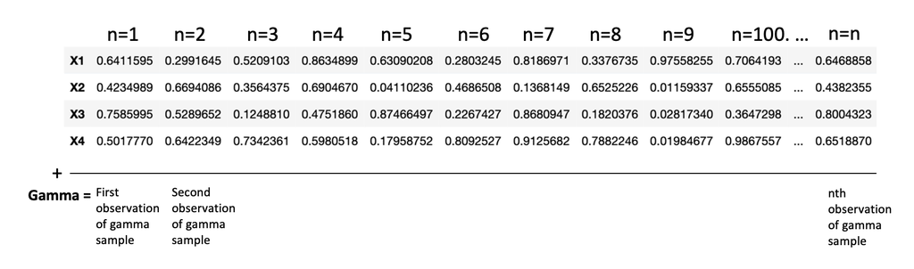

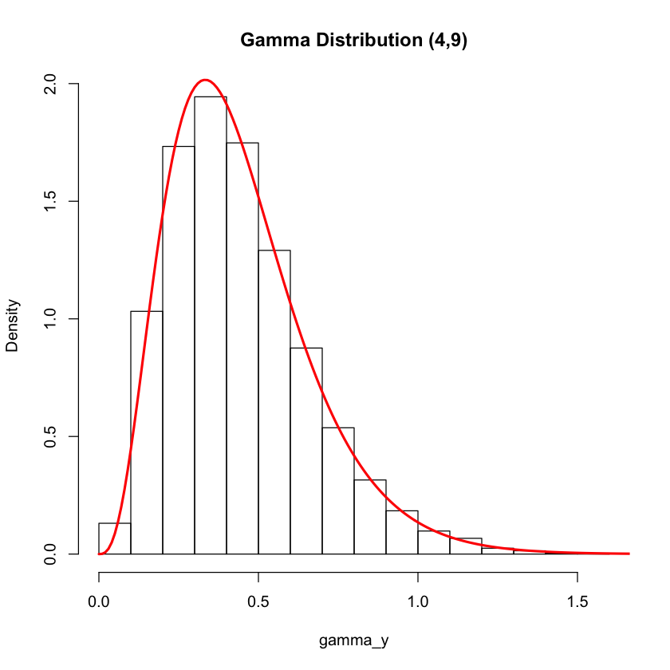

```r
logU <- -log(U) / lambda # inverse transform method

gamma_y <- apply(logU,2,sum) # col sums of matrix logU

hist(gamma_y, prob=TRUE, main ="Gamma Distribution (4,9)")
y = seq(0,2.5,0.01)
lines(y,dgamma(y,t,lambda),col="red",lwd = 2.5)
```

```r
#theoratical parameters
theoratical_mean <- t/lambda
theoratical_var <- t/lambda^2

#sample statistics
est_mean <- mean(gamma_y)
est_var <- var(gamma_y)

control <- matrix(round(c(theoratical_mean,theoratical_var, est_mean,est_var),5), nrow = 2, byrow = T)


colnames(control) <- c("Mean","Variance")
rownames(control) <- c("Theoritical", "Estimated")
control
```

|  | Mean | Variance |
| --- | --- | --- |
| Theoritical | 0.44444 | 0.04938 |
| Estimated | 0.44201 | 0.04864 |

### Q2)

Generate a sample of size $n=10^5$ from Pareto(1, 18) by using relation between Exponential(8), Erlang and Pareto distributions. Try to use only runif(1) function to generate random variables.

Also, show that your sample has the properties of Pareto(1,18).

Let X is a random variable from Pareto Distribution(1,18) and its PDF is

### f(X)= $\frac{\alpha \beta^\alpha}{x^{\alpha+1}}$

We know that the sum of t independent Exponential(8) is distributed as Erlang(t,8). This leads the following transformation based on t uniform random numbers.

Remember from Recitation 2 we had shown that the inverse transform of Exponential distribution is

### X= -$\frac{1}{\lambda}logU$

Then, to generate a random sample from Erlang Distribution we can use inverse transform method for exponential distribution;

### Y = -$\frac{1}{\lambda}logU_1$ -$\frac{1}{\lambda}log_2$ ... -$\frac{1}{\lambda}logU_t$

Then,

### Z= $\frac{U}{V}+1 \sim Pareto(1, t)$

```r
library(sads)
```

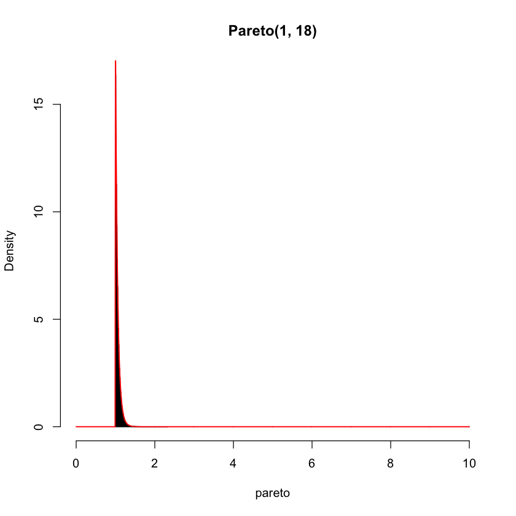

```r
set.seed(361)

#parameters
n <- 10^5
t <- 18
lambda <- 8

U <- matrix(runif(n*t),nrow = t, ncol = n)

exponential <- -log(U) / lambda # inverse transform method
erlang <- apply(exponential,2,sum) # col sums of matrix logU

pareto = (exponential/erlang) + 1

hist(pareto, prob=TRUE, xlim = c(0, 10),
     breaks = 100,
     main = "Pareto(1, 18)")
y = seq(0,10,0.01)
lines(y, dpareto(y,  scale = 1, shape=t, log = FALSE),col="red",lwd = 1.5)
```

## Q3)

Generate random sample of size $10^5$ from $\chi^2$ distribution with 10 degrees of freedom by using the relation between Chi-Square and standard normal distribution. Check the histogram and compare estimated mean and variance with the theoritical expectation and variance of $\chi^2_{(v)}$ distribution (v=10).

E(x)=v and V(x) = 2v

### We can use the fact that the chi-square distribution with V degrees of freedom is the sum of V squared independent standard normal;

Z $\sim N(0, 1)$ and X=$\sum_1^{10}Z_i^2= Z_1+Z_2+Z_3+...+Z_{10} \sim \chi^2_{10}$

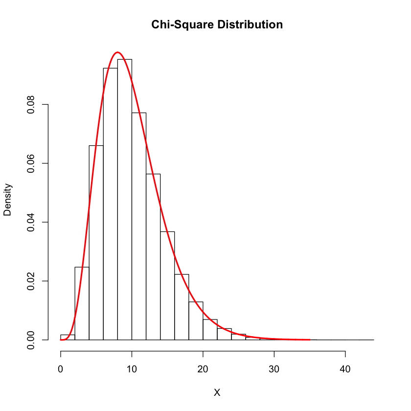

```r
set.seed(361)
n <- 10^5
v <- 10


Z <- matrix(rnorm(v*n,0,1),nrow = v, ncol = n)
SquaredZ <- Z^2

X <- colSums(SquaredZ)

hist(X, prob=TRUE, main ="Chi-Square Distribution")
y = seq(0,35,0.01)
lines(y,dchisq(y,v),col="red",lwd = 2.5)
```

```r
#theoratical parameters
theoratical_mean <- v
theoratical_var <- 2*v

#sample statistics
est_mean <- mean(X)
est_var <- var(X)

control <- matrix(round(c(theoratical_mean,theoratical_var, est_mean,est_var),5), nrow = 2, byrow = T)


colnames(control) <- c("Mean","Variance")
rownames(control) <- c("Theoritical", "Estimated")
control
```

|  | Mean | Variance |
| --- | --- | --- |
| Theoritical | 10.00000 | 20.00000 |
| Estimated | 9.99888 | 19.90146 |

## Q4)

Generate random sample of size $n=10^5$ from Student-T distribution with 40 degrees of freedom by using the following transformation method. Compare the histogram with the Student-T density curve.

Hint: If $𝑍 \sim N(0, 1)$ and $V \sim \chi^2_t$ are independent,

Then; T = $\frac{Z}{\sqrt {V/t}} \sim t_t$ has the Student-T distribution with t degrees of freedom.

Generate $\chi^2$ random variables from standard normal distribution.

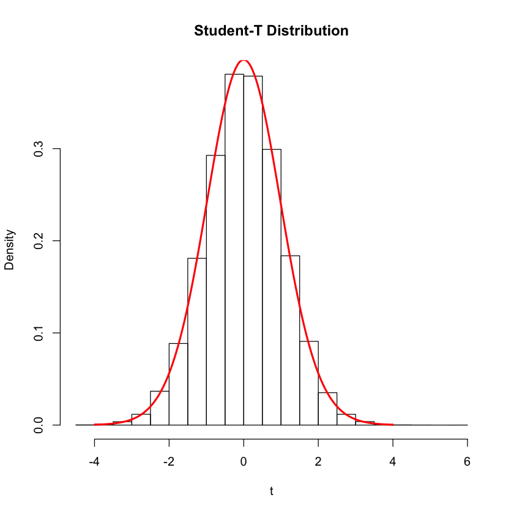

```r
set.seed(361)
n <- 10^5
v <- 40


Z1 <- rnorm(n) #standard normal dist

Z2 <- matrix(rnorm(n*v),v,n)
Z2_sqr <- Z2^2
V <- colSums(Z2_sqr) #chi-square dist with 40 dof


t <- Z1 / (sqrt(V / v))

hist(t, prob = TRUE, main = "Student-T Distribution")
y <- seq(-4,4,0.01)
lines(y, dt(y,v),col = "Red", lwd = 2.5)
```

## Q5)

Let X is a random variable from Logistic Distribution$(\mu,s)$ and its PDF is;

$$ f(x) = \frac{e^{\frac{-(x-\mu)}{s}}}{s(1 + e^{\frac{-(x-\mu)}{s}})^2} $$

Generate random sample of size $n=10^5$ from Logistic(5, 7) by using the following transformation method. Compare the histogram with the Logistic density curve.

### X $\sim Exponential(1)$ 𝑎𝑛𝑑 $Y \sim Exponential(1)$

### Z= $\mu - slog(\frac{X}{Y}) \sim Logistic(\mu, s)$

Remember from Recitation 2 we had shown that the inverse transform of Exponential distribution is

### X= -$\frac{1}{\lambda}logU$

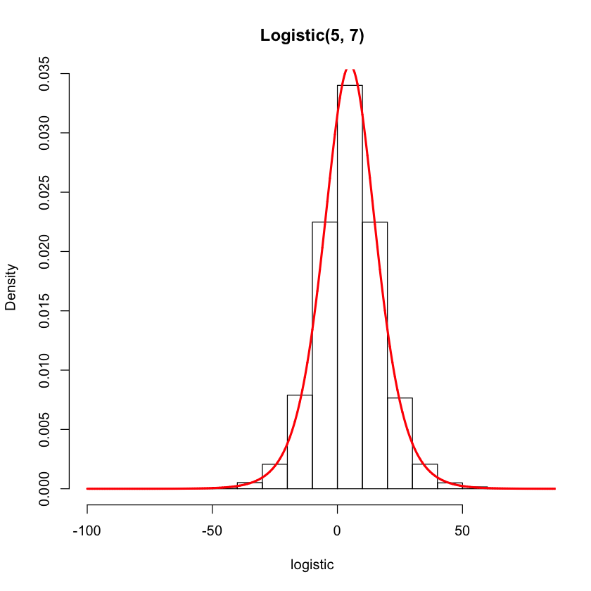

```r
set.seed(361)

n<- 10^5
lambda <- 1
mu = 5
s = 7

u1 <- runif(n)
x <- -log(u1) / lambda # inverse transform method for first exponnetial variable


u2 <- runif(n)
y <- -log(u2) / lambda # inverse transform method for second exponnetial variable




logistic <- mu-(s*log(x/y))




hist(logistic, prob = TRUE, main = "Logistic(5, 7)")
a <- seq(-100,100,0.01)
lines(a, (exp(-(a-mu)/s) / (s*(1 + exp(-(a-mu)/s))^2)),col = "Red", lwd = 2.5)
```

## Q6)

Let X is a random variable from F Distribution$(2, 8)$

Generate random sample of size $n=10^5$ from $F_{(2, 8)}$ by using the following transformation method. Compare the histogram with the F density curve.

### $V_1 \sim \chi^2_{k}$ and $V_2 \sim \chi^2_{l} $ then,

### F = $\frac{V_1/k}{V_2/l} \sim F_{k, l}$

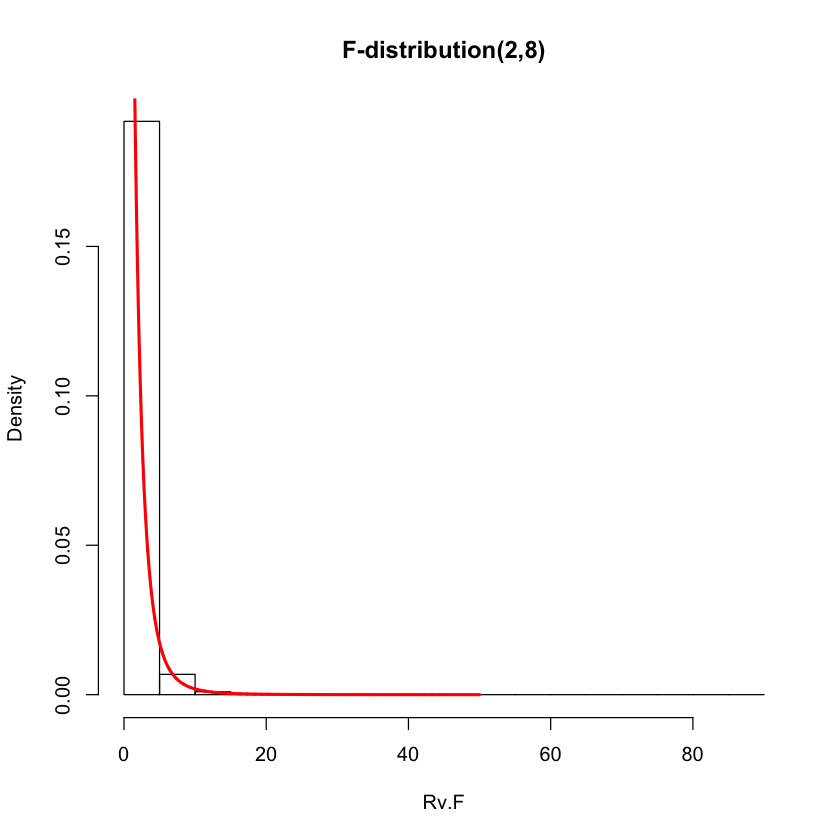

```r
N <- 10^5
m <- 2
n <- 8


z1 <- matrix(rnorm(m*N),m,N) #standard normal matrix
z2 <- matrix(rnorm(n*N),n,N) #standard normal matrix

squared_z1 <- z1^2 #chi-square 1 dof matrix
squared_z2 <- z2^2 #chi-square 1 dof matrix

U <- colSums(squared_z1) #chi-square 2 dof
V <- colSums(squared_z2) #chi-square 8 dof

Rv.F <- (U/m)/(V/n) # F(2,8)

hist(Rv.F, prob = T, main = "F-distribution(2,8)")

a <- seq(0,50,0.01)
lines(a,df(a,m,n), col = "red", lwd = 2.5)
```